# Demographics Stats - PhysioNet Sepsis Challenge

efg | 2019-03-03

# 1 Purpose

The purpose of this notebook is to take a preliminary look at the raw data from 5000 patients in the PhysioNet 2019 challenge, where some had sepsis and some did not.

The focus of this notebook is on the Demographics data (columns 35-40 in the raw files):

| Quantity | Units | Description |
| --- | --- | --- |
| `Age` | Years |  |
| `Gender` |  | Female (0) or Male (1) |
| `Unit1` |  | Administrative identifier for ICU unit (MICU) |
| `Unit2` |  | Administrative identifier for ICU unit (SICU) |
| `HospAdmTime` | Hours | Time between hospital admit and ICU admit |
| `ICULOS` | Hours | ICU length-of-stay (hours since ICU admit) |

and the outcome (column 41)

- `SepsisLabel`. For sepsis patients, `SepsisLabel` is 1 if $t \ge t_{sepsis} - 6$ and 0 if $t < t_{sepsis} - 6$. For non-sepsis patients, `SepsisLabel` is 0.

# 2 Background

The data being analyzed is from the [Early Prediction of Sepsis from Clinical Data: the PhysioNet/Computing in Cardiology Challenge 2019](https://physionet.org/challenge/2019/).

# 3 Exploration

## 3.1 Setup

```r
plotCaptionLeft  <- "PhysioNet 2019 Sepsis Project"
plotCaptionRight <- paste("efg", format(Sys.time(), "%Y-%m-%d"))
```

```r
LOSbreaks <- c(1, 8, 12, 18, 24, 30, 36, 48,
                             60, 72, 96, 192, 336)
```

### 3.1.1 Packages

```r
library(tidyverse)
library(writexl)
library(kableExtra) # kable_styling
```

### 3.1.2 Helper function

```r
Show <- function(data, caption="", bigMark="", ...)
{
  data                                          %>%
  kable("html",
        caption=caption,
        format.args = list(big.mark=bigMark))   %>%
  kable_styling(bootstrap_options = c("striped", "bordered", "condensed"),
                position = "left", full_width = FALSE, ...)
}
```

### 3.1.3 Load PhysioNet 2019 Challenge Combined Data

```r
load(file = "../../data/PhysioNet-2019-Raw-Data.RData")
dim(allData)
```

```
[1] 188453     42
```

Sample records

```r
allData    %>%
  head(50) %>%
  Show()   %>%
  scroll_box(width = "800px", height = "500px")
```

| patient | ICULOS | HR | O2Sat | Temp | SBP | MAP | DBP | Resp | EtCO2 | BaseExcess | HCO3 | FiO2 | pH | PaCO2 | SaO2 | AST | BUN | Alkalinephos | Calcium | Chloride | Creatinine | Bilirubin_direct | Glucose | Lactate | Magnesium | Phosphate | Potassium | Bilirubin_total | TroponinI | … |
| --- | --- | --- | --- | --- | --- | --- | --- | --- | --- | --- | --- | --- | --- | --- | --- | --- | --- | --- | --- | --- | --- | --- | --- | --- | --- | --- | --- | --- | --- | --- |
| p00001 | 1 | NA | NA | NA | NA | NA | NA | NA | NA | NA | NA | NA | NA | NA | NA | NA | NA | NA | NA | NA | NA | NA | NA | NA | NA | NA | NA | NA | NA | … |
| p00001 | 2 | 93.0 | 92.5 | NA | 110.0 | 76.0 | 56.0 | 22.0 | NA | NA | NA | NA | NA | NA | NA | NA | NA | NA | NA | NA | NA | NA | NA | NA | NA | NA | NA | NA | NA | … |
| p00001 | 3 | 91.0 | 96.0 | NA | 108.0 | 84.5 | 72.0 | 23.5 | NA | NA | NA | NA | NA | NA | NA | NA | NA | NA | NA | NA | NA | NA | 233 | NA | NA | NA | NA | NA | NA | … |
| p00001 | 4 | 93.0 | 98.0 | NA | 123.0 | 87.0 | 61.0 | 21.0 | NA | NA | NA | NA | NA | NA | NA | NA | NA | NA | NA | NA | NA | NA | NA | NA | NA | NA | NA | NA | NA | … |
| p00001 | 5 | 93.0 | 95.0 | NA | 110.0 | 81.0 | 70.0 | 20.0 | NA | NA | NA | NA | NA | NA | NA | NA | NA | NA | NA | NA | NA | NA | NA | NA | NA | NA | NA | NA | NA | … |
| p00001 | 6 | NA | NA | NA | NA | NA | NA | NA | NA | NA | NA | NA | NA | NA | NA | NA | NA | NA | NA | NA | NA | NA | NA | NA | NA | NA | NA | NA | NA | … |
| p00001 | 7 | 91.5 | 97.0 | 36.5 | 104.0 | 75.0 | 60.0 | 20.0 | NA | NA | NA | NA | NA | NA | NA | NA | NA | NA | NA | NA | NA | NA | NA | NA | NA | NA | NA | NA | NA | … |
| p00001 | 8 | 94.0 | 95.0 | NA | 114.0 | 85.0 | 66.0 | 20.0 | NA | NA | NA | NA | NA | NA | NA | NA | NA | NA | NA | NA | NA | NA | 154 | NA | 2.1 | NA | 3.7 | NA | NA | … |
| p00001 | 9 | 94.0 | 95.0 | NA | 121.0 | 88.0 | 69.0 | 20.0 | NA | NA | NA | NA | NA | NA | NA | NA | NA | NA | NA | NA | NA | NA | NA | NA | NA | NA | NA | NA | NA | … |
| p00001 | 10 | 102.0 | 95.0 | NA | 117.0 | 89.0 | 70.0 | 20.0 | NA | NA | NA | NA | NA | NA | NA | NA | NA | NA | NA | NA | NA | NA | NA | NA | NA | NA | NA | NA | NA | … |
| p00001 | 11 | 106.0 | 97.0 | 36.8 | 107.0 | 82.0 | 68.0 | 20.0 | NA | NA | NA | NA | NA | NA | NA | NA | NA | NA | NA | NA | NA | NA | NA | NA | NA | NA | NA | NA | NA | … |
| p00001 | 12 | 107.0 | 95.0 | NA | 112.0 | 86.0 | 67.0 | 20.0 | NA | NA | NA | NA | NA | NA | NA | NA | NA | NA | NA | NA | NA | NA | NA | NA | NA | NA | NA | NA | NA | … |
| p00001 | 13 | 102.0 | 95.0 | NA | 108.0 | 80.0 | 59.0 | 20.0 | NA | NA | NA | NA | NA | NA | NA | NA | 30 | NA | 7.8 | NA | 1.50 | NA | 112 | NA | 2.0 | NA | 4.2 | NA | NA | … |
| p00001 | 14 | 98.0 | 95.0 | NA | 112.0 | 81.0 | 61.0 | 20.0 | NA | NA | NA | NA | NA | NA | NA | NA | NA | NA | NA | NA | NA | NA | NA | NA | NA | NA | NA | NA | NA | … |
| p00001 | 15 | 95.0 | 96.0 | 36.6 | 110.0 | 82.0 | 61.0 | 20.0 | NA | NA | NA | NA | NA | NA | NA | NA | NA | NA | NA | NA | NA | NA | NA | NA | NA | NA | NA | NA | NA | … |
| p00001 | 16 | 105.0 | 94.0 | NA | 119.0 | 86.0 | 63.0 | 22.0 | NA | NA | NA | NA | NA | NA | NA | NA | NA | NA | NA | NA | NA | NA | NA | NA | NA | NA | NA | NA | NA | … |
| p00001 | 17 | 94.0 | 93.0 | NA | 114.0 | 84.0 | 63.0 | 16.0 | NA | NA | NA | NA | NA | NA | NA | NA | NA | NA | NA | NA | NA | NA | 123 | NA | NA | NA | NA | NA | NA | … |
| p00001 | 18 | 98.0 | 97.0 | NA | 116.0 | 84.0 | 63.0 | 22.0 | NA | NA | NA | NA | NA | NA | NA | NA | NA | NA | NA | NA | NA | NA | NA | NA | NA | NA | NA | NA | NA | … |
| p00001 | 19 | 98.0 | 99.0 | 36.9 | 121.0 | 86.0 | 62.0 | 18.0 | NA | NA | NA | NA | NA | NA | NA | NA | NA | NA | NA | NA | NA | NA | NA | NA | NA | NA | NA | NA | NA | … |
| p00001 | 20 | 105.0 | 95.0 | NA | 106.0 | 76.0 | 55.0 | 18.0 | NA | NA | NA | NA | NA | NA | NA | NA | NA | NA | NA | NA | NA | NA | NA | NA | NA | NA | NA | NA | NA | … |
| p00001 | 21 | 96.0 | 93.0 | NA | 110.0 | 81.0 | 62.0 | 16.0 | NA | NA | NA | NA | NA | NA | NA | NA | NA | NA | NA | NA | NA | NA | NA | NA | NA | NA | NA | NA | NA | … |
| p00001 | 22 | 102.0 | 96.0 | NA | 115.0 | 85.0 | 67.0 | 18.0 | NA | NA | NA | NA | NA | NA | NA | NA | NA | NA | NA | NA | NA | NA | NA | NA | NA | NA | NA | NA | NA | … |
| p00001 | 23 | 105.0 | 97.0 | 37.0 | 108.0 | 83.0 | 69.0 | 16.0 | NA | NA | NA | NA | NA | NA | NA | NA | NA | NA | NA | NA | NA | NA | 123 | NA | NA | NA | NA | NA | NA | … |
| p00001 | 24 | 107.0 | 92.0 | NA | 116.0 | 87.0 | 70.0 | 16.0 | NA | NA | NA | NA | NA | NA | NA | NA | NA | NA | NA | NA | NA | NA | NA | NA | NA | NA | NA | NA | NA | … |
| p00002 | 1 | NA | NA | NA | NA | NA | NA | NA | NA | NA | NA | NA | NA | NA | NA | NA | NA | NA | NA | NA | NA | NA | NA | NA | NA | NA | NA | NA | NA | … |
| p00002 | 2 | 56.5 | 100.0 | 35.2 | 129.0 | 75.0 | 52.5 | 23.0 | 35.0 | NA | NA | NA | NA | NA | NA | NA | NA | NA | NA | NA | NA | NA | NA | NA | NA | NA | NA | NA | NA | … |
| p00002 | 3 | 61.0 | 100.0 | 35.8 | 86.0 | 56.0 | 43.0 | 17.0 | 39.0 | NA | NA | NA | NA | NA | NA | NA | NA | NA | NA | NA | NA | NA | 110 | NA | NA | NA | NA | NA | NA | … |
| p00002 | 4 | 64.5 | 99.0 | 36.9 | 103.0 | 59.0 | 41.0 | 20.0 | 37.5 | NA | NA | NA | NA | NA | NA | NA | NA | NA | NA | NA | NA | NA | NA | NA | NA | NA | NA | NA | NA | … |
| p00002 | 5 | 71.5 | 97.0 | 37.2 | 136.5 | 81.5 | 52.5 | 22.5 | NA | NA | NA | NA | NA | NA | NA | NA | NA | NA | NA | NA | NA | NA | NA | NA | NA | NA | NA | NA | NA | … |
| p00002 | 6 | 67.0 | 98.0 | 37.4 | 145.0 | 87.0 | 61.0 | 26.0 | NA | NA | NA | NA | NA | NA | NA | NA | NA | NA | NA | NA | NA | NA | 68 | NA | NA | NA | NA | NA | NA | … |
| p00002 | 7 | 67.0 | 99.0 | 37.5 | 142.0 | 87.0 | 63.0 | 22.0 | NA | NA | NA | NA | NA | NA | NA | NA | NA | NA | NA | NA | NA | NA | 216 | NA | NA | NA | NA | NA | NA | … |
| p00002 | 8 | 67.0 | 99.0 | 37.7 | 152.0 | 92.0 | 65.0 | 24.0 | NA | NA | NA | NA | NA | NA | NA | NA | NA | NA | NA | NA | NA | NA | NA | NA | NA | NA | NA | NA | NA | … |
| p00002 | 9 | 66.0 | 99.0 | 37.7 | 157.0 | 93.0 | 66.0 | 20.0 | NA | NA | NA | NA | NA | NA | NA | NA | NA | NA | NA | NA | NA | NA | 222 | NA | 2.3 | 1.8 | 3.8 | NA | NA | … |
| p00002 | 10 | 64.0 | 99.0 | 37.7 | 136.0 | 86.0 | 68.0 | 16.0 | NA | NA | NA | NA | NA | NA | NA | NA | NA | NA | NA | NA | NA | NA | 175 | NA | NA | NA | NA | NA | NA | … |
| p00002 | 11 | 67.0 | 97.0 | 37.5 | 135.0 | 86.0 | 65.0 | 20.0 | NA | NA | NA | NA | NA | NA | NA | NA | NA | NA | NA | NA | NA | NA | 94 | NA | NA | NA | NA | NA | NA | … |
| p00002 | 12 | 67.0 | 95.0 | 37.5 | 139.0 | 85.0 | 62.0 | 26.0 | NA | NA | NA | NA | NA | NA | NA | NA | NA | NA | NA | NA | NA | NA | NA | NA | NA | NA | NA | NA | NA | … |
| p00002 | 13 | 69.0 | 99.0 | 37.6 | 126.0 | 78.0 | 60.0 | 18.0 | NA | NA | NA | NA | NA | NA | NA | NA | NA | NA | NA | NA | NA | NA | 92 | NA | NA | NA | NA | NA | NA | … |
| p00002 | 14 | 62.0 | 96.0 | 37.4 | 109.0 | 65.0 | 47.0 | 22.0 | NA | NA | NA | NA | NA | NA | NA | NA | NA | NA | NA | NA | NA | NA | NA | NA | NA | NA | NA | NA | NA | … |
| p00002 | 15 | 63.0 | 97.0 | 37.4 | 122.0 | 83.0 | 66.0 | 22.0 | NA | NA | NA | NA | NA | NA | NA | NA | 17 | NA | 8.2 | NA | 0.84 | NA | 106 | NA | 2.2 | 3.6 | 5.2 | NA | NA | … |
| p00002 | 16 | 62.0 | 98.0 | 37.4 | 115.0 | 87.0 | 67.0 | 24.0 | NA | NA | NA | NA | NA | NA | NA | NA | NA | NA | NA | NA | NA | NA | NA | NA | NA | NA | NA | NA | NA | … |
| p00002 | 17 | 64.0 | 99.0 | 37.3 | 100.0 | 77.0 | 64.0 | 22.0 | NA | NA | NA | NA | NA | NA | NA | NA | NA | NA | NA | NA | NA | NA | 116 | NA | NA | NA | NA | NA | 3.7 | … |
| p00002 | 18 | 64.0 | 95.0 | 37.4 | 118.0 | 84.0 | 66.0 | 26.0 | NA | NA | NA | NA | NA | NA | NA | NA | NA | NA | NA | NA | NA | NA | NA | NA | NA | NA | NA | NA | NA | … |
| p00002 | 19 | NA | NA | NA | NA | NA | NA | NA | NA | NA | NA | NA | NA | NA | NA | NA | NA | NA | NA | NA | NA | NA | 122 | NA | NA | NA | NA | NA | NA | … |
| p00002 | 20 | 63.0 | 100.0 | 37.5 | 139.0 | 91.0 | 67.0 | 22.0 | NA | NA | NA | NA | NA | NA | NA | NA | NA | NA | NA | NA | NA | NA | NA | NA | NA | NA | 4.7 | NA | NA | … |
| p00002 | 21 | 66.0 | 94.0 | 37.5 | 133.0 | 82.0 | 60.0 | 22.5 | NA | NA | NA | NA | NA | NA | NA | NA | NA | NA | NA | NA | NA | NA | NA | NA | NA | NA | NA | NA | NA | … |
| p00002 | 22 | 64.0 | 98.0 | 37.5 | 149.0 | 95.0 | 71.0 | 20.0 | NA | NA | NA | NA | NA | NA | NA | NA | NA | NA | NA | NA | NA | NA | 111 | NA | NA | NA | NA | NA | NA | … |
| p00002 | 23 | 69.0 | 99.0 | 37.9 | 128.0 | 83.0 | 62.0 | 22.0 | NA | NA | NA | NA | NA | NA | NA | NA | NA | NA | NA | NA | NA | NA | NA | NA | NA | NA | NA | NA | NA | … |
| p00002 | 24 | 58.0 | 98.0 | 37.7 | 100.0 | 65.0 | 50.0 | 23.0 | NA | NA | NA | NA | NA | NA | NA | NA | NA | NA | NA | NA | NA | NA | NA | NA | NA | NA | NA | NA | NA | … |
| p00002 | 25 | 56.0 | 96.0 | 37.9 | 121.0 | 68.5 | 49.5 | 22.0 | NA | NA | NA | NA | NA | NA | NA | NA | NA | NA | NA | NA | NA | NA | 139 | NA | NA | NA | NA | NA | NA | … |
| p00003 | 1 | NA | NA | NA | NA | NA | NA | NA | NA | NA | NA | NA | NA | NA | NA | NA | NA | NA | NA | NA | NA | NA | NA | NA | NA | NA | NA | NA | NA | … |

### 3.1.4 Create Patient Summary

Verify certain values are constant for a patient

Not shown here, but I verified Age, Gender, Unit1 and Unit2 were constant for each patient.

Shown here is proof that HospAdmTime does not change by patient.

```r
allData              %>%
  group_by(patient)  %>%
  summarize(minHospAdmTime = min(HospAdmTime),
            maxHospAdmTime = max(HospAdmTime))  %>%
  ungroup()          %>%
  filter(minHospAdmTime != maxHospAdmTime)      %>%
  Show()
```

| patient | minHospAdmTime | maxHospAdmTime |
| --- | --- | --- |

So, let’s grab the first value for most quantities, but verify range of ICULOS.

```r
patientSummary <-
  allData                               %>%

  group_by(patient)                     %>%
  summarize(nRecord     = n(),
            Age         = Age[1],
            Gender      = Gender[1],
            Unit1       = Unit1[1],
            Unit2       = Unit2[1],
            HospAdmTime = HospAdmTime[1],
            minICULOS   = min(ICULOS),
            maxICULOS   = max(ICULOS),
            gapICULOS   = max(diff(ICULOS)),
            Sepsis      = max(SepsisLabel),
            SepsisHours = sum(SepsisLabel),
            FirstSepsisHour = ICULOS[which(SepsisLabel == 1)][1],
            LastSepsisHour  = ICULOS[rev( which(SepsisLabel == 1) )][1],
            Duration        = LastSepsisHour - FirstSepsisHour + 1) %>%
  ungroup()                             %>%

  mutate(Gender = recode(Gender,
                         "0" = "Female",
                         "1" = "Male"),
         Sepsis = recode(Sepsis,
                         "0" = "Non-Sepsis",
                         "1" = "Sepsis"))

nrow(patientSummary)
```

```
[1] 5000
```

```r
patientSummary %>%
  head()       %>%
  Show(font_size = 9)
```

| patient | nRecord | Age | Gender | Unit1 | Unit2 | HospAdmTime | minICULOS | maxICULOS | gapICULOS | Sepsis | SepsisHours | FirstSepsisHour | LastSepsisHour | Duration |
| --- | --- | --- | --- | --- | --- | --- | --- | --- | --- | --- | --- | --- | --- | --- |
| p00001 | 24 | 73 | Male | 1 | 0 | -214.64 | 1 | 24 | 1 | Non-Sepsis | 0 | NA | NA | NA |
| p00002 | 25 | 83 | Male | 0 | 1 | -123.17 | 1 | 25 | 1 | Non-Sepsis | 0 | NA | NA | NA |
| p00003 | 43 | 48 | Male | NA | NA | -2.83 | 1 | 43 | 1 | Non-Sepsis | 0 | NA | NA | NA |
| p00004 | 59 | 67 | Male | 1 | 0 | -1.93 | 1 | 59 | 1 | Non-Sepsis | 0 | NA | NA | NA |
| p00005 | 52 | 50 | Male | 1 | 0 | -3.27 | 1 | 52 | 1 | Non-Sepsis | 0 | NA | NA | NA |
| p00006 | 47 | 50 | Male | NA | NA | 0.00 | 6 | 52 | 1 | Non-Sepsis | 0 | NA | NA | NA |

Save file for review in Excel

```r
write_xlsx(patientSummary, "Patient-Sepsis-Summary.xlsx")
```

```r
patientSummary  %>%
  group_by(SepsisHours) %>%
  count()       %>%
  Show()
```

| SepsisHours | n |
| --- | --- |
| 0 | 4721 |
| 1 | 1 |
| 6 | 2 |
| 7 | 1 |
| 8 | 44 |
| 9 | 59 |
| 10 | 172 |

## 3.2 Sepsis Label

### 3.2.1 By Raw Data Record

Only about 1.4% of raw records indicate sepsis.

```r
table(allData$SepsisLabel, useNA = "ifany")
```

```
     0      1
185830   2623
```

### 3.2.2 By Patient

Only about 5.6% of the patients have sepsis.

```r
table(patientSummary$Sepsis, useNA = "ifany")
```

```
Non-Sepsis     Sepsis
      4721        279
```

### 3.2.3 First Hour Sepsis Indicated

Let’s recall the definition of `SepsisLabel`: For sepsis patients, `SepsisLabel` is 1 if $t \ge t_{sepsis} - 6$ and 0 if $t < t_{sepsis} - 6$. For non-sepsis patients, `SepsisLabel` is 0.

In a [posting to physionet, Matthew Reyna said](https://groups.google.com/forum/m/#!topic/physionet-challenges/fKwge1jq0Jg):

> …although the sepsis rate is ~22%, we exclude patients who come to the ICU with sepsis or who develop sepsis within 4 hours of their ICU stay, resulting in a sepsis rate of 5.6% in our training data. The fraction of windows labeled as septic is even smaller because patients who eventually develop sepsis typically have several non-septic windows prior to sepsis onset.

> …to encourage the early prediction of sepsis, the first window with SepsisLabel = 1 is before the onset time of sepsis, which is given by `t_sepsis` in the “Challenge Data” section of the website. Therefore, although 20.1% of sepsis patients in the training data have `SepsisLabel = 1` in the first hour, this does not mean that 20.1% of sepsis patients were identified as septic upon admission – as above, we excluded these patients.

But there is an unexpected spike in the first hour (see below) for `SepsisLabel`, which means sepsis for those cases starts in the 6th hour? How does that make sense, when all other hours are so much lower?

```r
firstSepsisHourCounts <-
  patientSummary              %>%
  filter(Sepsis == "Sepsis")  %>%
  group_by(FirstSepsisHour)   %>%
  count()                     %>%
  ungroup()

nrow(firstSepsisHourCounts)
```

```
[1] 112
```

Sepsis reported in first hour for 20.1% of sepsis patients.

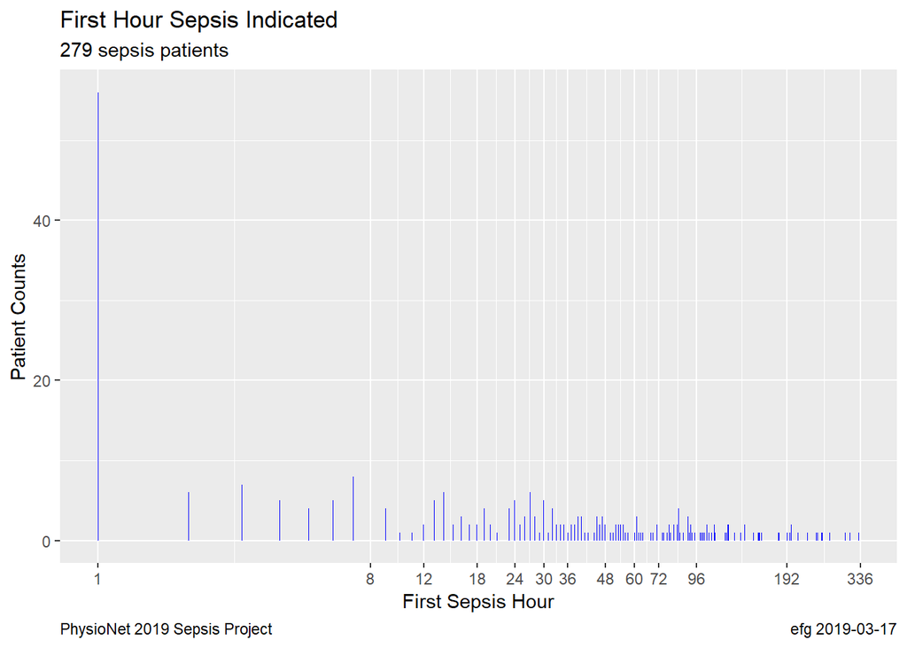

```r
firstSepsisHourCounts     %>%
  ggplot(aes(x = FirstSepsisHour, y = n))                        +
    geom_bar(stat = "identity", fill="blue")                     +
    scale_x_log10(breaks = LOSbreaks)                            +
    labs(title = "First Hour Sepsis Indicated",
         subtitle = paste(sum(firstSepsisHourCounts$n), "sepsis patients"),
         x = "First Sepsis Hour",
         y = "Patient Counts",
         caption = c(plotCaptionLeft, plotCaptionRight))         +
    theme(plot.caption = element_text(hjust=c(0.0,1.0)))
```

```r
firstSepsisHourCounts  %>%
  head(10)             %>%
  Show()
```

| FirstSepsisHour | n |
| --- | --- |
| 1 | 56 |
| 2 | 6 |
| 3 | 7 |
| 4 | 5 |
| 5 | 4 |
| 6 | 5 |
| 7 | 8 |
| 9 | 4 |
| 10 | 1 |
| 11 | 1 |

### 3.2.4 Sepsis Time Span

How many hours from first to last sepsis record for a sepsis patient?

```r
sepsisSpanHours <-
  patientSummary              %>%
  filter(Sepsis == "Sepsis")  %>%
  group_by(Duration)          %>%
  count()                     %>%
  ungroup()

nrow(sepsisSpanHours)
```

```
[1] 6
```

```r
Show(sepsisSpanHours)
```

| Duration | n |
| --- | --- |
| 1 | 1 |
| 6 | 2 |
| 7 | 1 |
| 8 | 44 |
| 9 | 59 |
| 10 | 172 |

### 3.2.5 Sepsis Time Span for Patients with Sepsis Indicated First Hour

```r
patientSummary                  %>%
  filter(Sepsis == "Sepsis",
         FirstSepsisHour == 1)  %>%
  group_by(Duration)            %>%
  count()                       %>%
  ungroup()                     %>%
  Show()
```

| Duration | n |
| --- | --- |
| 8 | 42 |
| 9 | 8 |
| 10 | 6 |

Does LastSepsisHour always match maxICULOS?

```r
patientSummary                         %>%
  filter(Sepsis == "Sepsis",
         maxICULOS == LastSepsisHour)  %>%
  count()                              %>%
  Show()
```

| n |
| --- |
| 279 |

Yes!

### 3.2.6 Example Sepsis patients with FirstSepsisHour = 1

#### 3.2.6.1 67 year old female

```r
example1 <-
  allData                      %>%
  filter(patient == "p00055")
nrow(example1)
```

```
[1] 8
```

```r
example1 %>% Show()
```

| patient | ICULOS | HR | O2Sat | Temp | SBP | MAP | DBP | Resp | EtCO2 | BaseExcess | HCO3 | FiO2 | pH | PaCO2 | SaO2 | AST | BUN | Alkalinephos | Calcium | Chloride | Creatinine | Bilirubin_direct | Glucose | Lactate | Magnesium | Phosphate | Potassium | Bilirubin_total | TroponinI | … |
| --- | --- | --- | --- | --- | --- | --- | --- | --- | --- | --- | --- | --- | --- | --- | --- | --- | --- | --- | --- | --- | --- | --- | --- | --- | --- | --- | --- | --- | --- | --- |
| p00055 | 1 | NA | NA | NA | NA | NA | NA | NA | NA | NA | NA | NA | NA | NA | NA | NA | NA | NA | NA | NA | NA | NA | NA | NA | NA | NA | NA | NA | NA | … |
| p00055 | 2 | 56 | 100 | NA | 115 | 81 | 56 | 18 | NA | NA | NA | NA | NA | NA | NA | NA | NA | NA | NA | NA | NA | NA | NA | NA | NA | NA | NA | NA | NA | … |
| p00055 | 3 | 71 | 98 | 35.6 | 105 | 76 | 54 | 20 | NA | NA | NA | NA | NA | NA | NA | NA | NA | NA | NA | NA | NA | NA | 122 | NA | NA | NA | NA | NA | NA | … |
| p00055 | 4 | 64 | 100 | NA | 122 | 86 | 62 | 21 | NA | NA | NA | NA | NA | NA | NA | NA | NA | NA | NA | NA | NA | NA | NA | NA | NA | NA | NA | NA | NA | … |
| p00055 | 5 | 69 | 100 | NA | 137 | 89 | 62 | 23 | NA | NA | NA | NA | NA | NA | NA | NA | NA | NA | NA | NA | NA | NA | NA | NA | NA | NA | NA | NA | NA | … |
| p00055 | 6 | 66 | 100 | NA | 124 | 83 | 58 | 22 | NA | NA | NA | NA | NA | NA | NA | NA | NA | NA | NA | NA | NA | NA | NA | NA | NA | NA | NA | NA | NA | … |
| p00055 | 7 | 56 | 100 | 35.6 | 137 | 91 | 63 | 22 | NA | NA | NA | NA | NA | NA | NA | NA | NA | NA | NA | NA | NA | NA | 113 | NA | NA | NA | NA | NA | NA | … |
| p00055 | 8 | 60 | 100 | NA | 145 | 92 | 64 | 24 | NA | NA | NA | NA | NA | NA | NA | NA | NA | NA | NA | NA | NA | NA | NA | NA | NA | NA | NA | NA | NA | … |

#### 3.2.6.2 55 year old male

```r
allData                        %>%
  filter(patient == "p01072")  %>%
  Show()
```

| patient | ICULOS | HR | O2Sat | Temp | SBP | MAP | DBP | Resp | EtCO2 | BaseExcess | HCO3 | FiO2 | pH | PaCO2 | SaO2 | AST | BUN | Alkalinephos | Calcium | Chloride | Creatinine | Bilirubin_direct | Glucose | Lactate | Magnesium | Phosphate | Potassium | Bilirubin_total | TroponinI | … |
| --- | --- | --- | --- | --- | --- | --- | --- | --- | --- | --- | --- | --- | --- | --- | --- | --- | --- | --- | --- | --- | --- | --- | --- | --- | --- | --- | --- | --- | --- | --- |
| p01072 | 1 | NA | NA | NA | NA | NA | NA | NA | NA | NA | NA | NA | NA | NA | NA | NA | NA | NA | NA | NA | NA | NA | NA | NA | NA | NA | NA | NA | NA | … |
| p01072 | 2 | 114 | 99.0 | NA | 168 | 100.0 | 68.0 | 17 | 42.0 | NA | NA | NA | NA | NA | NA | 22 | 26 | 41 | 7.40 | NA | 0.66 | NA | 119 | NA | NA | NA | 4.3 | 0.4 | NA | … |
| p01072 | 3 | 95 | 100.0 | NA | 110 | 67.0 | 49.0 | NA | 45.0 | NA | NA | 0.5 | 7.48 | 45 | 98.4 | NA | NA | NA | 1.09 | NA | NA | NA | 110 | 1.41 | NA | NA | 4.2 | NA | NA | … |
| p01072 | 4 | 89 | 99.5 | 37.4 | 140 | 78.0 | 54.0 | 8 | 46.0 | NA | NA | NA | NA | NA | NA | NA | NA | NA | NA | NA | NA | NA | NA | NA | NA | NA | NA | NA | NA | … |
| p01072 | 5 | 97 | 98.5 | NA | 150 | 83.0 | 59.0 | NA | 53.0 | NA | NA | NA | NA | NA | NA | NA | NA | NA | NA | NA | NA | NA | NA | NA | NA | NA | NA | NA | NA | … |
| p01072 | 6 | 106 | 100.0 | NA | 122 | 68.0 | 50.0 | NA | 51.0 | NA | NA | 0.4 | 7.47 | 47 | 98.1 | NA | NA | NA | 1.09 | NA | NA | NA | 112 | 1.49 | NA | NA | 3.9 | NA | NA | … |
| p01072 | 7 | 108 | 99.0 | NA | 106 | 62.0 | 46.0 | NA | 56.0 | NA | NA | NA | NA | NA | NA | NA | NA | NA | NA | NA | NA | NA | NA | NA | NA | NA | NA | NA | NA | … |
| p01072 | 8 | 112 | 99.0 | 37.5 | 107 | 66.5 | 50.5 | NA | 45.5 | NA | NA | NA | NA | NA | NA | NA | NA | NA | NA | NA | NA | NA | NA | NA | NA | NA | NA | NA | NA | … |
| p01072 | 9 | 109 | 99.5 | NA | 117 | 64.0 | 46.0 | NA | 40.5 | NA | NA | NA | NA | NA | NA | NA | NA | NA | NA | NA | NA | NA | 83 | NA | NA | NA | NA | NA | NA | … |
| p01072 | 10 | 114 | 97.5 | NA | 203 | 114.0 | 76.0 | NA | 49.0 | NA | NA | NA | NA | NA | NA | NA | NA | NA | NA | NA | NA | NA | NA | NA | NA | NA | NA | NA | NA | … |

## 3.3 Raw Records Per Patient

There is one record per hour, but the first patient record is sometimes not hour 1.

### 3.3.1 All Patients

The median number of records per patient is 38.

```r
quantile(patientSummary$nRecord,
         c(0.0, 0.01, 0.10, 0.25, 0.50, 0.75, 0.90, 0.99, 1.00))
```

```
    0%     1%    10%    25%    50%    75%    90%    99%   100%
  8.00   8.00  17.00  23.00  38.00  47.00  54.00 111.01 336.00
```

```r
recordsPerPatient <-
  patientSummary       %>%
  group_by(nRecord)    %>%
  count()              %>%
  ungroup()
```

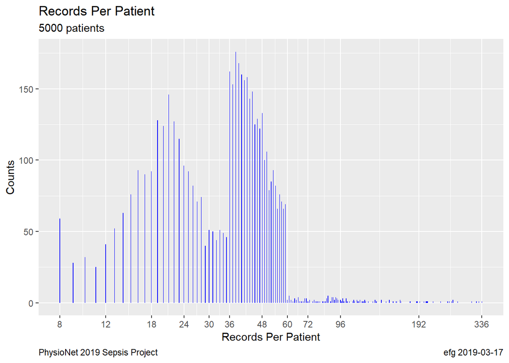

```r
recordsPerPatient                                               %>%
  ggplot(aes(x = nRecord, y = n))                                +
    geom_bar(stat = "identity", fill="blue")                     +
    scale_x_log10(breaks = LOSbreaks)                            +
    labs(title = "Records Per Patient",
         subtitle = paste(sum(recordsPerPatient$n), "patients"),
         x = "Records Per Patient",
         y = "Counts",
         caption = c(plotCaptionLeft, plotCaptionRight))         +
    theme(plot.caption = element_text(hjust=c(0.0,1.0)))
```

### 3.3.2 Sepsis Patients

```r
recordsPerSepsisPatient <-
  patientSummary              %>%
  filter(Sepsis == "Sepsis")  %>%
  group_by(nRecord)           %>%
  count()                     %>%
  ungroup()
```

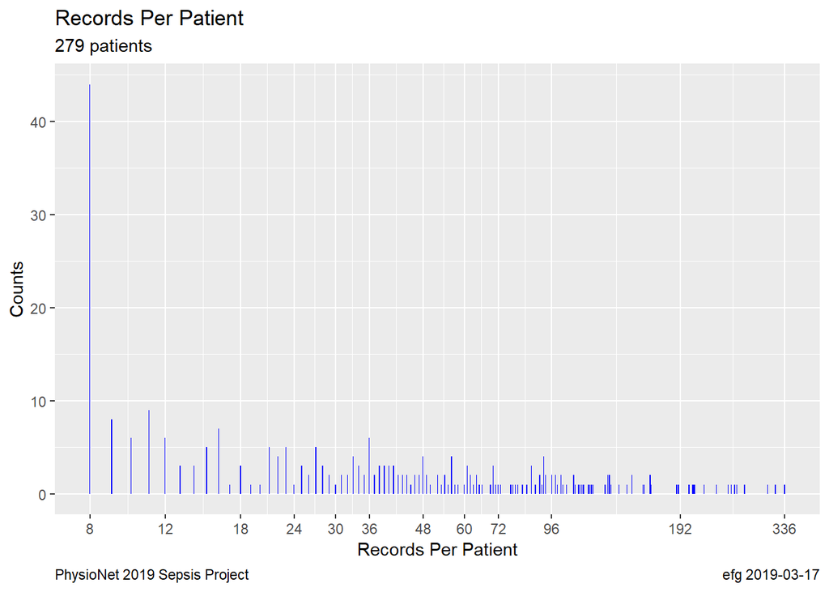

```r
recordsPerSepsisPatient                                         %>%
  ggplot(aes(x = nRecord, y = n))                                +
    geom_bar(stat = "identity", fill="blue")                     +
    scale_x_log10(breaks = LOSbreaks)                            +
    labs(title = "Records Per Patient",
         subtitle = paste(sum(recordsPerSepsisPatient$n), "patients"),
         x = "Records Per Patient",
         y = "Counts",
         caption = c(plotCaptionLeft, plotCaptionRight))         +
    theme(plot.caption = element_text(hjust=c(0.0,1.0)))
```

## 3.4 Age

### 3.4.1 All Patients

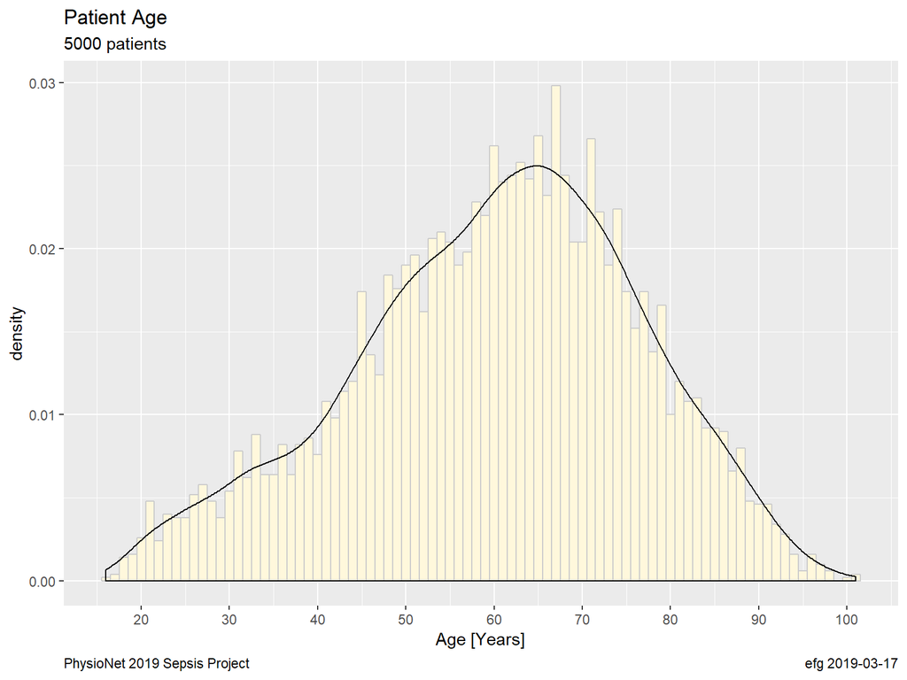

```r
patientSummary                                                 %>%
  ggplot(aes(x = Age, y = ..density..))                         +
    geom_histogram(fill="cornsilk", color="grey80", binwidth=1) +
    geom_density()                                              +
    scale_x_continuous(breaks = 10 * 1:10)                      +
    labs(title    = "Patient Age",
         subtitle = paste(nrow(patientSummary), "patients"),
         x = "Age [Years]",
         caption = c(plotCaptionLeft, plotCaptionRight))        +
    theme(plot.caption = element_text(hjust=c(0.0,1.0)))
```

### 3.4.2 By Sepsis Status

```r
sepsisCounts   <- table(patientSummary$Sepsis, useNA="ifany")
sepsisFacetName <- paste0(names(sepsisCounts), "[", sepsisCounts, "]")

sepsisLabeller <- function(variable, value)
{
  return(sepsisFacetName[value])
}
```

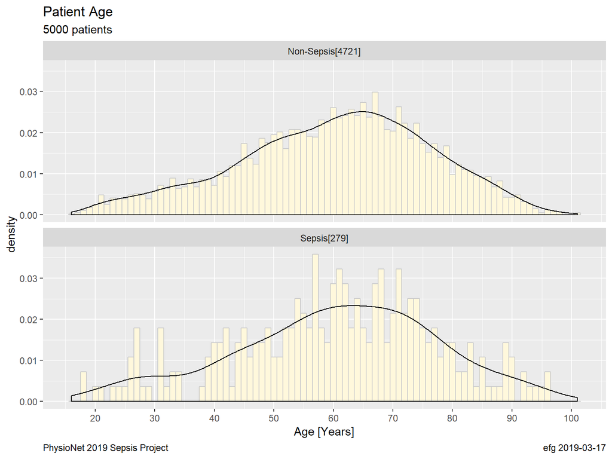

```r
patientSummary                                                 %>%
  ggplot(aes(x = Age, y = ..density..))                         +
    geom_histogram(fill="cornsilk", color="grey80", binwidth=1) +
    geom_density()                                              +
    scale_x_continuous(breaks = 10 * 1:10)                      +
    labs(title    = "Patient Age",
         subtitle = paste(nrow(patientSummary), "patients"),
         x = "Age [Years]",
         caption = c(plotCaptionLeft, plotCaptionRight))        +
    theme(plot.caption = element_text(hjust=c(0.0,1.0)))        +
    facet_wrap(~Sepsis, nrow=2, labeller = as_labeller(sepsisLabeller))
```

### 3.4.3 By Gender

```r
genderCounts   <- table(patientSummary$Gender, useNA="ifany")
genderFacetName <- paste0(names(genderCounts), "[", genderCounts, "]")

genderLabeller <- function(variable, value)
{
  return(genderFacetName[value])
}
```

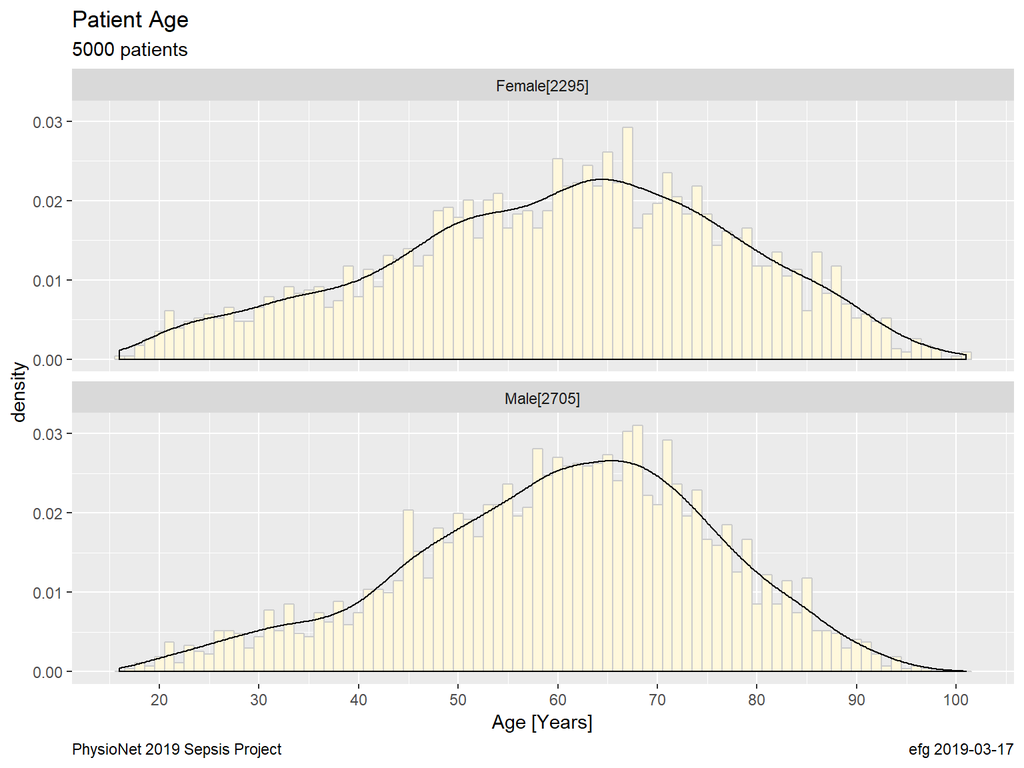

```r
patientSummary                                                 %>%
  ggplot(aes(x = Age, y = ..density..))                         +
    geom_histogram(fill="cornsilk", color="grey80", binwidth=1) +
    geom_density()                                              +
    scale_x_continuous(breaks = 10 * 1:10)                      +
    labs(title    = "Patient Age",
         subtitle = paste(nrow(patientSummary), "patients"),
         x = "Age [Years]",
         caption = c(plotCaptionLeft, plotCaptionRight))        +
    theme(plot.caption = element_text(hjust=c(0.0,1.0)))        +
    facet_wrap(~Gender, nrow=2, labeller = as_labeller(genderLabeller))
```

## 3.5 Gender

```r
table(patientSummary$Gender, useNA = "ifany")
```

```
Female   Male
  2295   2705
```

```r
table(patientSummary$Sepsis, patientSummary$Gender, useNA = "ifany")
```

```
             Female Male
  Non-Sepsis   2173 2548
  Sepsis        122  157
```

## 3.6 Units

Not sure how to use this information

### 3.6.1 Unit 1

```r
table(patientSummary$Unit1, useNA = "ifany")
```

```
   0    1 <NA>
1757 1752 1491
```

### 3.6.2 Unit 2

```r
table(patientSummary$Unit2, useNA = "ifany")
```

```
   0    1 <NA>
1752 1757 1491
```

### 3.6.3 Unit 1 and 2 are mutually exclusive when known

```r
table(patientSummary$Unit1, patientSummary$Unit2, useNA = "ifany")
```

```
          0    1 <NA>
  0       0 1757    0
  1    1752    0    0
  <NA>    0    0 1491
```

## 3.7 Hospital Admit Time

Hours between hospital admit and ICU admit

#### 3.7.0.1 All Patients

Some large negative values

```r
quantile(patientSummary$HospAdmTime,
         c(0.0, 0.01, 0.05, 0.10, 0.25, 0.50, 0.75, 0.90, 0.95, 0.99, 1.00))
```

```
        0%         1%         5%        10%        25%        50%
-5366.8600  -556.4445  -249.8080  -162.3100   -51.7850    -8.4350
       75%        90%        95%        99%       100%
   -3.3775    -0.0700     0.0000     0.0000     0.0000
```

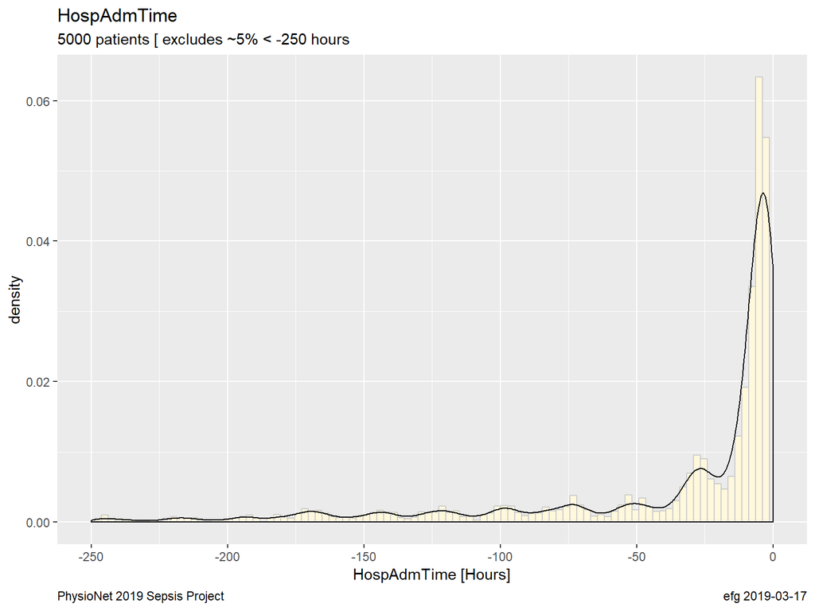

```r
patientSummary                                                  %>%
  ggplot(aes(x = HospAdmTime, y = ..density..))                  +
    geom_histogram(fill="cornsilk", color="grey80", bins=100)    +
    geom_density()                                               +
    xlim(-250, 0)                                                +
    labs(title    = "HospAdmTime",
         subtitle = paste(nrow(patientSummary), "patients [",
                          "excludes ~5% < -250 hours"),
         x = "HospAdmTime [Hours]",
         caption = c(plotCaptionLeft, plotCaptionRight))         +
    theme(plot.caption = element_text(hjust=c(0.0,1.0)))
```

#### 3.7.0.2 By Sepsis Status

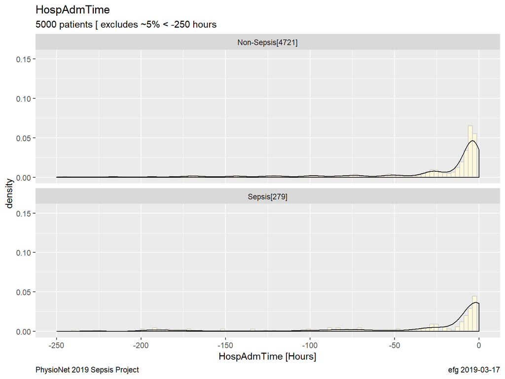

```r
patientSummary                                                  %>%
  ggplot(aes(x = HospAdmTime, y = ..density..))                  +
    geom_histogram(fill="cornsilk", color="grey80", bins=100)    +
    geom_density()                                               +
    xlim(-250, 0)                                                +
    labs(title    = "HospAdmTime",
         subtitle = paste(nrow(patientSummary), "patients [",
                          "excludes ~5% < -250 hours"),
         x = "HospAdmTime [Hours]",
         caption = c(plotCaptionLeft, plotCaptionRight))         +
    theme(plot.caption = element_text(hjust=c(0.0,1.0)))         +
    facet_wrap(~Sepsis, nrow=2, labeller = as_labeller(sepsisLabeller))
```

## 3.8 ICU length-of-stay

### 3.8.1 Always starts at hour 1?

```r
table(patientSummary$minICULOS, useNA = "ifany")
```

```
   1    2    3    4    5    6    7    8    9   13
4688  175   53   36   18   17    8    3    1    1
```

That’s not the case. Examples:

```r
patientSummary %>%
  filter(minICULOS > 8)  %>%
  Show()
```

| patient | nRecord | Age | Gender | Unit1 | Unit2 | HospAdmTime | minICULOS | maxICULOS | gapICULOS | Sepsis | SepsisHours | FirstSepsisHour | LastSepsisHour | Duration |
| --- | --- | --- | --- | --- | --- | --- | --- | --- | --- | --- | --- | --- | --- | --- |
| p01195 | 43 | 58 | Female | NA | NA | -352.65 | 9 | 51 | 1 | Non-Sepsis | 0 | NA | NA | NA |
| p04095 | 26 | 54 | Male | 0 | 1 | -69.82 | 13 | 38 | 1 | Non-Sepsis | 0 | NA | NA | NA |

Verified p01195 started at hour 9 and continued through hour 51.

### 3.8.2 Hourly gap(s) after first reported hour?

```r
table(patientSummary$gapICULOS, useNA = "ifany")
```

```
   1
5000
```

No gaps!

### 3.8.3 ICULOS All Patients

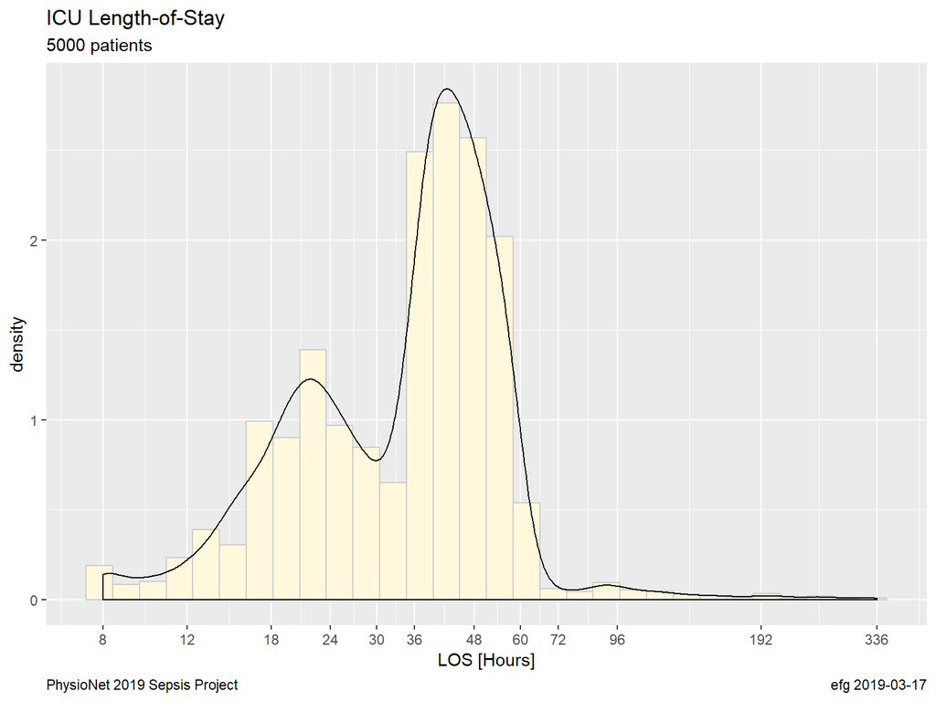

```r
patientSummary                                                  %>%
  ggplot(aes(x = maxICULOS, y = ..density..))                    +
    geom_histogram(fill="cornsilk", color="grey80", bins=30)     +
    geom_density()                                               +
    scale_x_log10(breaks = LOSbreaks)                            +
    labs(title    = "ICU Length-of-Stay",
         subtitle = paste(nrow(patientSummary), "patients"),
         x = "LOS [Hours]",
         caption = c(plotCaptionLeft, plotCaptionRight))         +
    theme(plot.caption = element_text(hjust=c(0.0,1.0)))
```

Bimodal peaks always beg for an interpretation!

### 3.8.4 ICULOS By Sepsis Status

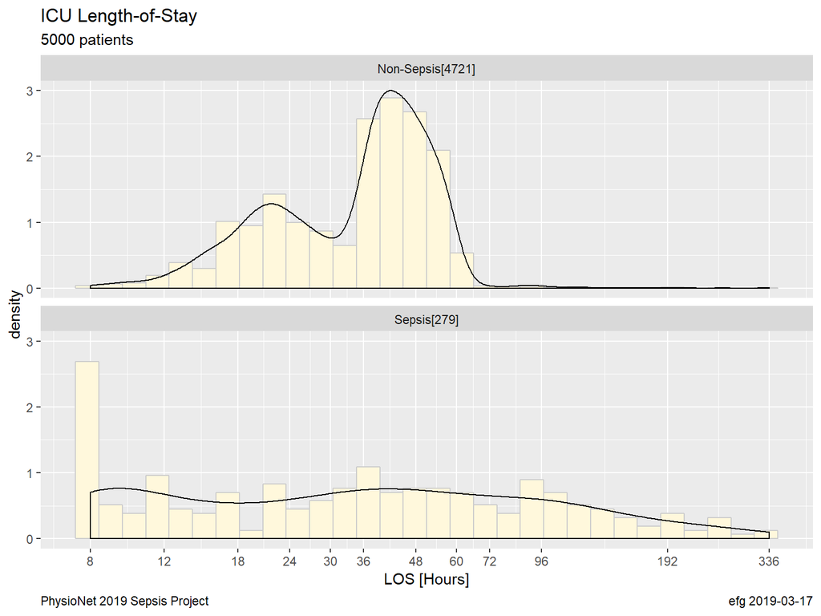

```r
patientSummary                                                  %>%
  ggplot(aes(x = maxICULOS, y = ..density..))                    +
    geom_histogram(fill="cornsilk", color="grey80", bins=30)     +
    geom_density()                                               +
    scale_x_log10(breaks = LOSbreaks)                            +
    labs(title    = "ICU Length-of-Stay",
         subtitle = paste(nrow(patientSummary), "patients"),
         x = "LOS [Hours]",
         caption = c(plotCaptionLeft, plotCaptionRight))         +
    theme(plot.caption = element_text(hjust=c(0.0,1.0)))         +
    facet_wrap(~Sepsis, nrow=2, labeller = as_labeller(sepsisLabeller))
```

Two modes not seen in sepsis patients.

## 3.9 ICU Hours Recorded

Nearly the same as number of records per patient.

```r
byHour <-
  allData                  %>%
  filter(SepsisLabel == 1) %>%
  group_by(ICULOS)         %>%
  count()                  %>%
  ungroup()
```

[figure not shown]

```r
byHour                                                          %>%
  ggplot(aes(x = ICULOS, y = n))                                 +
    geom_bar(stat = "identity", fill="blue")                     +
    #geom_density()                                              +
    scale_x_log10(breaks = LOSbreaks)                            +
    labs(title    = "ICULOS Hours (All Patients, All Hours)",
         subtitle = paste(nrow(allData), "records"),
         x = "ICULOS [Hour]",
         y = "Counts",
         caption = c(plotCaptionLeft, plotCaptionRight))         +
    theme(plot.caption = element_text(hjust=c(0.0,1.0)))
```

### 3.9.2 Sepsis Patients, All Hours

```r
byHourSepsisPatient <-
  patientSummary              %>%
  filter(Sepsis == "Sepsis")  %>%
  select(patient)             %>%
  inner_join(allData, by = "patient")  %>%
  group_by(ICULOS)            %>%
  count()                     %>%
  ungroup()

nrow(byHourSepsisPatient)
```

```
[1] 336
```

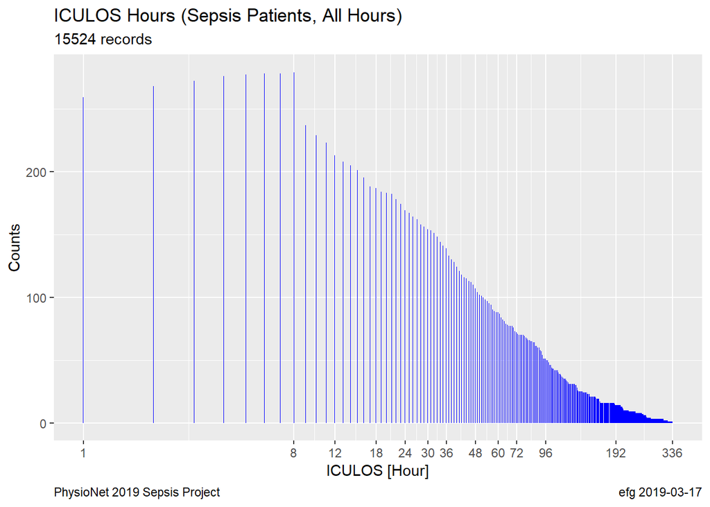

```r
byHourSepsisPatient                                             %>%
  ggplot(aes(x = ICULOS, y = n))                                 +
    geom_bar(stat = "identity", fill="blue")                     +
    #geom_density()                                              +
    scale_x_log10(breaks = LOSbreaks)                            +
    labs(title    = "ICULOS Hours (Sepsis Patients, All Hours)",
         subtitle = paste(sum(byHourSepsisPatient$n), "records"),
         x = "ICULOS [Hour]",
         y = "Counts",
         caption = c(plotCaptionLeft, plotCaptionRight))         +
    theme(plot.caption = element_text(hjust=c(0.0,1.0)))
```

### 3.9.3 Sepsis Patients, Sepsis Hours

```r
byHourSepsisPatient <-
  allData                     %>%
  filter(SepsisLabel == 1)    %>%
  group_by(ICULOS)            %>%
  count()                     %>%
  ungroup()

nrow(byHourSepsisPatient)
```

```
[1] 263
```

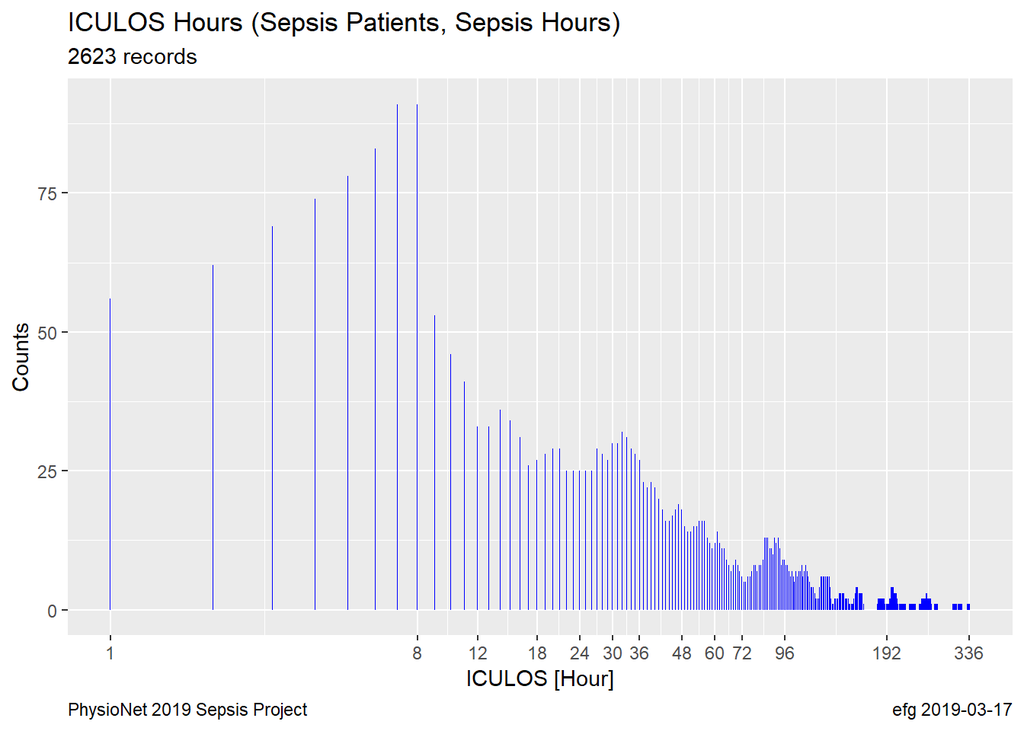

```r
byHourSepsisPatient                                             %>%
  ggplot(aes(x = ICULOS, y = n))                                 +
    geom_bar(stat = "identity", fill="blue")                     +
    scale_x_log10(breaks = LOSbreaks)                            +
    labs(title    = "ICULOS Hours (Sepsis Patients, Sepsis Hours)",
         subtitle = paste(sum(byHourSepsisPatient$n), "records"),
         x = "ICULOS [Hour]",
         y = "Counts",
         caption = c(plotCaptionLeft, plotCaptionRight))         +
    theme(plot.caption = element_text(hjust=c(0.0,1.0)))
```

# 4 Discussion

Only about 1.4% of raw records indicate sepsis.

Only about 5.6% of the patients have sepsis.

Sepsis reported in first hour for 20.1% of sepsis patients.

# 5 Conclusions

[work in progress]

Processing time: 11.1 secs

2019-03-17 2106